# Project Python Foundations: FoodHub Data Analysis

**Marks: 60**

### Context

The number of restaurants in New York is increasing day by day. Lots of students and busy professionals rely on those restaurants due to their hectic lifestyles. Online food delivery service is a great option for them. It provides them with good food from their favorite restaurants. A food aggregator company FoodHub offers access to multiple restaurants through a single smartphone app.

The app allows the restaurants to receive a direct online order from a customer. The app assigns a delivery person from the company to pick up the order after it is confirmed by the restaurant. The delivery person then uses the map to reach the restaurant and waits for the food package. Once the food package is handed over to the delivery person, he/she confirms the pick-up in the app and travels to the customer's location to deliver the food. The delivery person confirms the drop-off in the app after delivering the food package to the customer. The customer can rate the order in the app. The food aggregator earns money by collecting a fixed margin of the delivery order from the restaurants.

### Objective

The food aggregator company has stored the data of the different orders made by the registered customers in their online portal. They want to analyze the data to get a fair idea about the demand of different restaurants which will help them in enhancing their customer experience. Suppose you are hired as a Data Scientist in this company and the Data Science team has shared some of the key questions that need to be answered. Perform the data analysis to find answers to these questions that will help the company to improve the business.

### Data Description

The data contains the different data related to a food order. The detailed data dictionary is given below.

### Data Dictionary

- order_id: Unique ID of the order
- customer_id: ID of the customer who ordered the food
- restaurant_name: Name of the restaurant
- cuisine_type: Cuisine ordered by the customer
- cost: Cost of the order
- day_of_the_week: Indicates whether the order is placed on a weekday or weekend (The weekday is from Monday to Friday and the weekend is Saturday and Sunday)
- rating: Rating given by the customer out of 5
- food_preparation_time: Time (in minutes) taken by the restaurant to prepare the food. This is calculated by taking the difference between the timestamps of the restaurant's order confirmation and the delivery person's pick-up confirmation.
- delivery_time: Time (in minutes) taken by the delivery person to deliver the food package. This is calculated by taking the difference between the timestamps of the delivery person's pick-up confirmation and drop-off information

### Let us start by importing the required libraries

```python
# import libraries for data manipulation
import numpy as np
import pandas as pd

# import libraries for data visualization
import matplotlib.pyplot as plt
import seaborn as sns
```

### Understanding the structure of the data

```python
# uncomment and run the following lines for Google Colab
from google.colab import drive
drive.mount('/content/drive')
```

```python
# read the data
df = pd.read_csv('/content/drive/My Drive/Python Course/foodhub_order.csv')
# returns the first 5 rows
df.head()
```

|  | order_id | customer_id | restaurant_name | cuisine_type | cost_of_the_order | day_of_the_week | rating | food_preparation_time | delivery_time |
| --- | --- | --- | --- | --- | --- | --- | --- | --- | --- |
| 0 | 1477147 | 337525 | Hangawi | Korean | 30.75 | Weekend | Not given | 25 | 20 |
| 1 | 1477685 | 358141 | Blue Ribbon Sushi Izakaya | Japanese | 12.08 | Weekend | Not given | 25 | 23 |
| 2 | 1477070 | 66393 | Cafe Habana | Mexican | 12.23 | Weekday | 5 | 23 | 28 |
| 3 | 1477334 | 106968 | Blue Ribbon Fried Chicken | American | 29.20 | Weekend | 3 | 25 | 15 |
| 4 | 1478249 | 76942 | Dirty Bird to Go | American | 11.59 | Weekday | 4 | 25 | 24 |

#### Observations:

The DataFrame has 9 columns as mentioned in the Data Dictionary. Data in each row corresponds to the order placed by a customer.

### **Question 1:** How many rows and columns are present in the data? [0.5 mark]

```python
# Write your code here
df.shape
```

```
(1898, 9)
```

#### Observations:

There are about 1898 rows and 9 columns in the foodhub dataframe

### **Question 2:** What are the datatypes of the different columns in the dataset? (The info() function can be used) [0.5 mark]

```python
# Use info() to print a concise summary of the DataFrame
df.info()
```

```
<class 'pandas.core.frame.DataFrame'>
RangeIndex: 1898 entries, 0 to 1897
Data columns (total 9 columns):
 #   Column                 Non-Null Count  Dtype
---  ------                 --------------  -----
 0   order_id               1898 non-null   int64
 1   customer_id            1898 non-null   int64
 2   restaurant_name        1898 non-null   object
 3   cuisine_type           1898 non-null   object
 4   cost_of_the_order      1898 non-null   float64
 5   day_of_the_week        1898 non-null   object
 6   rating                 1898 non-null   object
 7   food_preparation_time  1898 non-null   int64
 8   delivery_time          1898 non-null   int64
dtypes: float64(1), int64(4), object(4)
memory usage: 133.6+ KB
```

#### Observations:

Order_id, customer_id, food_preparation_time, delivery_time has datatype = int64

restaurant_name, cuisine_type, day_of_the_week, rating has datatype = object / string

cost_of_the_order has datatype = float64

### **Question 3:** Are there any missing values in the data? If yes, treat them using an appropriate method. [1 mark]

```python
# Write your code here
df.isnull().sum()
```

```
order_id                 0
customer_id              0
restaurant_name          0
cuisine_type             0
cost_of_the_order        0
day_of_the_week          0
rating                   0
food_preparation_time    0
delivery_time            0
dtype: int64
```

#### Observations:

No missing values observed in any of the 9 columns across 1898 rows

### **Question 4:** Check the statistical summary of the data. What is the minimum, average, and maximum time it takes for food to be prepared once an order is placed? [2 marks]

```python
# Write your code here
df.describe()
```

|  | order_id | customer_id | cost_of_the_order | food_preparation_time | delivery_time |
| --- | --- | --- | --- | --- | --- |
| count | 1.898000e+03 | 1898.000000 | 1898.000000 | 1898.000000 | 1898.000000 |
| mean | 1.477496e+06 | 171168.478398 | 16.498851 | 27.371970 | 24.161749 |
| std | 5.480497e+02 | 113698.139743 | 7.483812 | 4.632481 | 4.972637 |
| min | 1.476547e+06 | 1311.000000 | 4.470000 | 20.000000 | 15.000000 |
| 25% | 1.477021e+06 | 77787.750000 | 12.080000 | 23.000000 | 20.000000 |
| 50% | 1.477496e+06 | 128600.000000 | 14.140000 | 27.000000 | 25.000000 |
| 75% | 1.477970e+06 | 270525.000000 | 22.297500 | 31.000000 | 28.000000 |
| max | 1.478444e+06 | 405334.000000 | 35.410000 | 35.000000 | 33.000000 |

[output not shown]

#### Observations:

food_preparation_time has min = 20 , max = 35 and mean = 27.371970

### **Question 5:** How many orders are not rated? [1 mark]

```python
# Write the code here
df['rating'].value_counts().reset_index(level=0)
```

|  | index | rating |
| --- | --- | --- |
| 0 | Not given | 736 |
| 1 | 5 | 588 |
| 2 | 4 | 386 |
| 3 | 3 | 188 |

#### Observations:

736 orders have not been rated

### Exploratory Data Analysis (EDA)

### **Question 6:** Explore all the variables and provide observations on their distributions. (Generally, histograms, boxplots, countplots, etc. are used for univariate exploration.) [9 marks]

**Histogram Plot of Delivery Time**

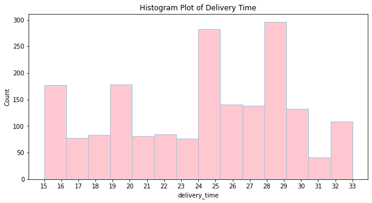

```python
# Write the code here
plt.figure(figsize=(10,5))
plt.title("Histogram Plot of Delivery Time")
histo = sns.histplot(x = "delivery_time" ,  data = df  , color='lightpink', ec="skyblue")
histo.set_xticks(np.arange(15,34,1))
plt.show()
```

# **Observations on Histogram Plot (Food Delivery Time):**

**Count Plot of Cuisine Type**

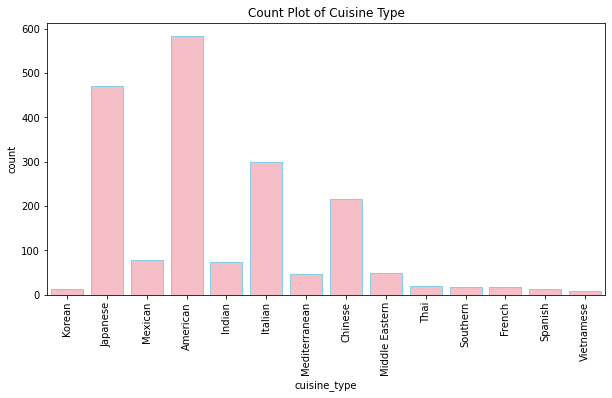

```python
# Write the code here
plt.figure(figsize=(10,5))
plt.title("Count Plot of Cuisine Type")
histo = sns.countplot(x = "cuisine_type" ,  data = df  , color='lightpink', ec="skyblue")
plt.xticks(rotation=90)
plt.show()
```

# **Observations on Count Plot (Cuisine Type):**

1. Highest number of orders were placed for American Cuisine ;
2. 2nd top is Japanese with approx 470 ;
3. Least number of orders were placed for Vietnamese cuisine

**Box Plot of Food Preparation Time**

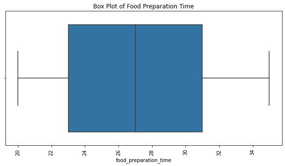

```python
# Write the code here
plt.figure(figsize=(10,5))
plt.title("Box Plot of Food Preparation Time")
histo = sns.boxplot(x = "food_preparation_time" ,  data = df  , hue ='rating')
plt.xticks(rotation=90)
plt.show()
```

# **Observations on Box Plot (Food Preparation Time):**

1. Min time to prepare the food is approx 20 min ;
2. Max time to prepare the food is approx 35 min ;
3. Median time to prepare the food is approx 27 min
4. Since median is in the middle of the box and the whiskers are roughly equal on each side, the distribution is symmetrical.

**Count Plot of Rating**

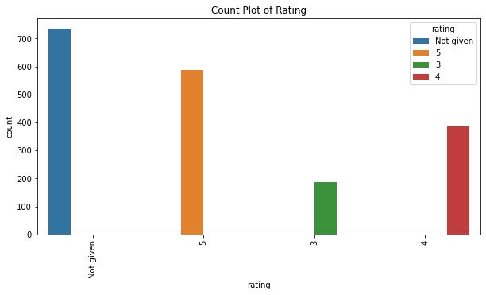

```python
# Write the code here
plt.figure(figsize=(10,5))
plt.title("Count Plot of Rating")
histo = sns.countplot(x = "rating" ,  data = df  , hue ='rating' )
plt.xticks(rotation=90)
plt.show()
```

# **Observations on Count Plot (Rating):**

1. Not Rated orders have a count of 736 ;
2. Orders that have been Rated as 5 are 588 ;
3. Orders that have been Rated as 4 are 386 ;
4. Orders that have been Rated as 3 are 188

**Count Plot of Day of the Week**

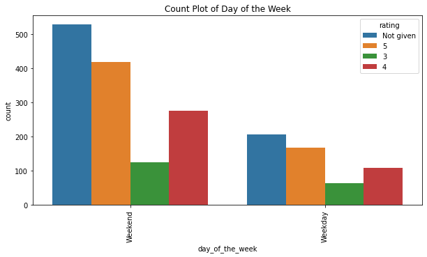

```python
# Write the code here
plt.figure(figsize=(10,5))
plt.title("Count Plot of Day of the Week")
histo = sns.countplot(x = "day_of_the_week" ,  data = df , hue ="rating" )
plt.xticks(rotation=90)
plt.show()
```

# **Observations on Count Plot(Day of the Week)**

1. Orders placed on weekend are higher (approx 1351) compared to weekday (approx 547)
2. Ratings comparison for orders placed b/w Weekday and weekend have a similar pattern :

   a) Not Rated orders are higher compared to those rated as 5

   b) Orders rated as 5 are higher compared to those rated as 4

   c) Orders rated as 4 are higher compared to those rated as 3

**Histogram Plot of Cost of the Food**

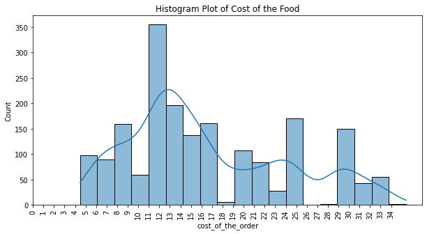

```python
# Write the code here
plt.figure(figsize=(10,5))
plt.title("Histogram Plot of Cost of the Food")
histo = sns.histplot(x = "cost_of_the_order" ,  data = df, kde=True  )
plt.xticks(rotation=90)
histo.set_xticks(np.arange(0,35,1))
plt.show()
```